# Chapter 4: Alternatives to the t-Tools

Loren

09/06/2014

# Computational Exercises

## 14. O-Ring Study

In warm temperatures, there were 17 launches with 0 incidents, 2 launches with one incident, etc.

```
## launch: COOL
##
## 1 3
## 3 1
## --------------------------------------------------------
## launch: WARM
##
##  0  1  2
## 17  2  1
```

A t-test on the data gives a p-value of 7.9292 × 10<sup>-4</sup>, whereas the exact p-value (from a permutation test) is 0.00988.

## 15. Artificial data: permutation test on differences of group means

```r
score <- c(1,5,4,8,9)
mean.diff <- mean(score[3:5]) - mean(score[1:2])
mean.diffs <- sort(aaply(combn(1:5,2), 2, function(x) { mean(score[-x]) - mean(score[x]) }))
names(mean.diffs) <- NULL
```

Group 1: 1, 5

Group 2: 4, 8, 9

Mean(group2) - Mean(group1) = 4.

The distribution of all such mean differences is [-5.1667, -2.6667, -1.8333, -1.8333, -1, 0.6667, 1.5, 1.5, 4, 4.8333].

2 of these are larger than or equal to 4, for a one-sided p-value of 0.2.

## 16. More artificial data: permutation distribution of difference in sample averages

Group 1: 5, 7, 12

Group 2: 4, 6

Mean(group1) - Mean(group2) = 3.

The distribution of such mean differences, from all regroupings, is [-4.5, -3.6667, -2.8333, -2, 0.5, 1.3333, 2.1667, 2.1667, 3, 3.8333].

4 of these mean differences are equal to or more extreme than 3, for a 2-sided p-value of 0.4.

## 18. A rank-sum test

The data:

Ranks 3,5, and 6 are in the treatment group. 1, 2, and 4 are in the control group. The sum of ranks in the treatment group is 14.

Here is the distribution of possible rank sums for the treatment group, based on all permutations of the ranks:

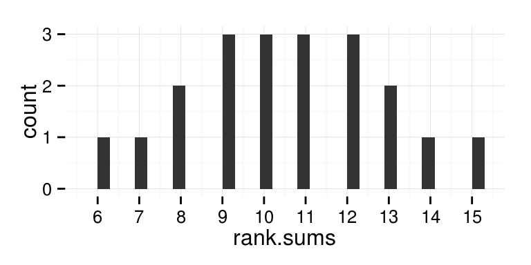

The graph shows that there are only 2 rank sums bigger than or equal to 14.

## 19. Bumpus with rank-sum

Plot of the data:

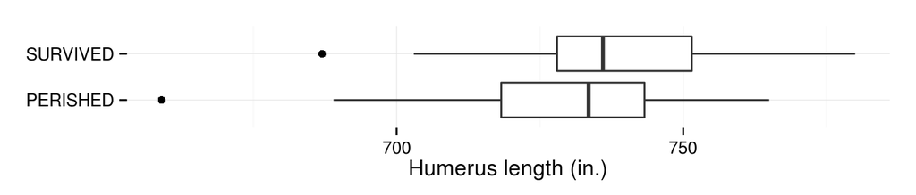

R’s default rank-sum test uses a continuity correction. It gives a warning that an exact p-value cannot be computed when there are ties:

```r
(wt <- wilcox.test(humerus ~ status, data=ex0419))
```

```
## Warning: cannot compute exact p-value with ties
```

```
##
##  Wilcoxon rank sum test with continuity correction
##
## data:  humerus by status
## W = 331, p-value = 0.1718
## alternative hypothesis: true location shift is not equal to 0
```

The reported 2-sided p-value, 0.1718, is much higher than 0.0809, the value from a t-test, but about the same as the p-value from a t-test in which the smallest observation has been removed: 0.176. TODO: interpret this.

## 20. Trauma and Metabolic Expenditure: rank-sum test “by hand”

Metabolic expenditures (kcal/kg/day)

Trauma patients: 22, 23, 24.5, 25.8, 30, 37.6, 38.5

Non-trauma patients: 18.8, 20, 20.1, 20.9, 20.9, 21.4, 22.7, 22.9

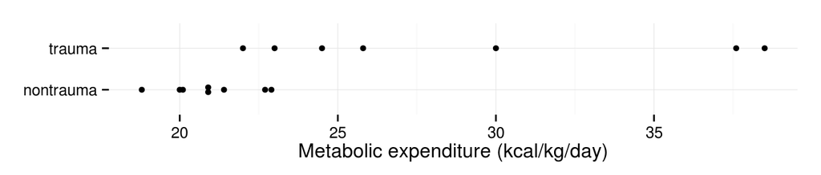

```r
ex0420$ranks <- rank(ex0420$expenditure)
```

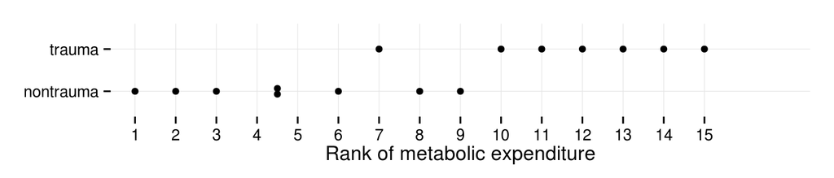

Rank sum for trauma group: 82

Mean of all ranks: 8

Sd of all ranks: 4.4681

Group sizes: 8, 7

Theoretical mean of trauma rank-sum: 56

Theoretical Sd of trauma rank-sum: 8.6333

Z-statistic: 3.0116

**One-sided p-value**: 0.0013

## 21. Trauma data: Checking exercise 20 using R’s wilcox.test

```r
(wt <- wilcox.test(expenditure ~ group, data=ex0420, alternative = 'less'))
```

```
##
##  Wilcoxon rank sum test with continuity correction
##
## data:  expenditure by group
## W = 2, p-value = 0.00157
## alternative hypothesis: true location shift is less than 0
```

**Check: p-value** (with continuity correction) = 0.0016

## 22. Trauma data: 95% confidence interval for the difference of population medians

The set-up. A function that tests whether a value is included in the interval:

```r
trauma <- with(ex0420, expenditure[group == 'trauma'])
nontrauma <- with(ex0420, expenditure[group == 'nontrauma'])

included <- function(delta) {
   # 2-sided p-value, see page 93:
   wilcox.test(trauma, nontrauma + delta)$p.value > .05
}
included <- Vectorize(included) # Can do it for multiple test-deltas at once
```

Median(trauma) - Median(nontrauma) = 4.9.

After some trial and error to find the endpoints:

```r
included(c(1.9, 1.91, 16.7, 16.71))
```

```
## [1] FALSE  TRUE  TRUE FALSE
```

So the 95% confidence interval is approximately (1.91, 16.7).

## 23. Motivation and Creativity: randomization test compared to t-test

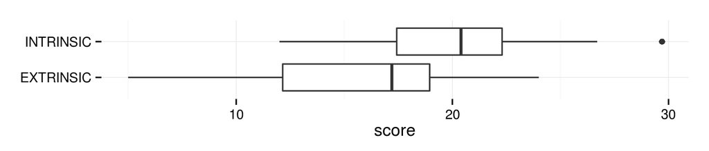

Group sizes:

```
##
## EXTRINSIC INTRINSIC
##        23        24
```

A randomization test:

```r
n <- 10000

mean.diffs <- numeric(n)
for (i in 1:n) {
   ex.ind <- sample(47, 23)
   mean.diffs[i] <- with(ex0423, mean(score[-ex.ind]) - mean(score[ex.ind]))
}
```

The observed difference in means:

```
## [1] 4.144
```

Plot of the simulated differences in means:

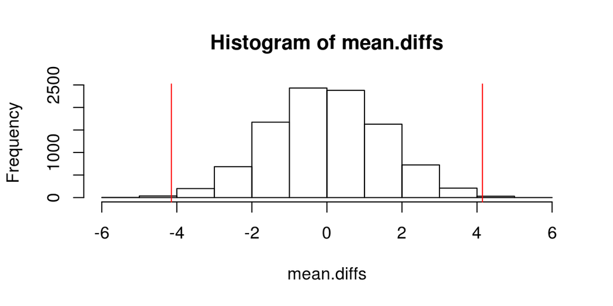

Out of 10<sup>4</sup> resamplings, only 48 gave rise to a difference of means as extreme as the observed one, giving a 2-sided p-value of 0.0048.

For comparison, the p-value of a t-test is 0.0054.

## 24. Creativity and Motivation: 95% confidence interval using rank-sum procedure

```r
intrinsic <- with(ex0423, score[treatment == 'INTRINSIC'])
extrinsic <- with(ex0423, score[treatment == 'EXTRINSIC'])

included <- function(delta) {
   # 2-sided p-value, see page 93:
   wilcox.test(intrinsic, extrinsic + delta)$p.value > .05
}
included <- Vectorize(included) # Can do it for multiple test-deltas at once
```

Median(intrinsic) - Median(extrinsic) = 3.2.

After some trial and error:

```r
included(c(1, 1.0001, 6.6, 6.601))
```

```
## [1] FALSE  TRUE  TRUE FALSE
```

So the confidence interval is about (1, 6.6). (That’s for intrinsic minus extrinsic).

For comparison, a t-test gives a confidence interval of -6.997, -1.2914. (That’s for extrinsic minus intrinsic).

## 25. Guinea Pig Lifetimes: Welch t-test

A Welch-test gives 2-sided p-value 0.0017 and 95% confidence interval (-165.8069, -39.5929) for (bacilli - control). However, the distribution is unusual. The control group seems to be bimodal and the bacilli distribution is shaped very differently. The additive treatment model assumes that the treatment makes the same difference (?), on each individual to which it is applied, hence that the two distributions are shaped the same. That doesn’t seem to be the case here.

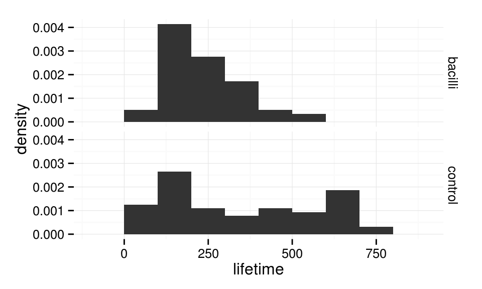

## 26. Schizophrenia - log-transforms

```r
ex0426 <- sleuth.read('ascii/case0202.csv')
```

The un-transformed differences in hippocampus volume:

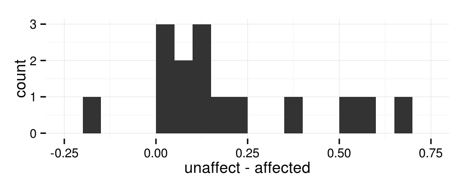

Are the data skewed? Perhaps, but only perhaps. Can you tell which QQ-plot is the data? (It’s the top-center one). The other plots are generated from a normal distribution.

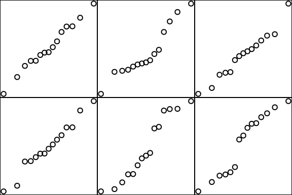

The problem asks to log the volumes.

```r
ex0426$diff.of.logs <- with(ex0426, log(unaffect) - log(affected))
```

For reference, a paired t-test on the untransfored data gives p-val = 0.0061 and 95% confidence interval (0.0667, 0.3306). The mean difference in volume is estimated to be 0.1987.

A paired t-test on the difference of the logged brain volumes gives p-val = 0.0065 and 95% confidence interval of (0.0423, 0.2147). The mean difference in logged volume is estimated to be 0.1285. That means that the median of the ratios of the volumes is estimated to be 1.1371, and the median of the ratios has a 95% confidence interval of (1.0432, 1.2395).